# BIOSTAT 707 — Checkpoint 1: Set A cohort preparation and description

Author

Bowen Zhang (bz147)

Published

September 16, 2026

## Setup

This checkpoint preserves the reproducible long table and adds measurement-quality and temporal missingness analyses. It also constructs the initial wide table, Table 1, and descriptive outcome summaries. No prediction model is fitted.

```r
here::i_am("checkpoint1.qmd")
library(data.table)
source(here::here("R", "load-set-a.R"))
source(here::here("R", "audit-missingness.R"))
source(here::here("R", "build-wide.R"))
source(here::here("R", "informative-missingness.R"))
library(ggplot2)
# Confirm that all available package libraries belong to the Pixi environment.
prefix <- normalizePath(Sys.getenv("CONDA_PREFIX"), mustWork = TRUE)
stopifnot(all(startsWith(normalizePath(.libPaths()), paste0(prefix, "/"))))
```

## Data locations and reproducibility

Run `pixi run --locked checkpoint1` from the repository root. The supplied `pixi.toml` and `pixi.lock` specify the environment; raw data and generated CSVs are excluded from Git. Set A must be supplied locally in `data/set-a/`. Neither raw patient files nor outcomes are downloaded by this pipeline.

```r
raw_dir <- here::here("data", "set-a")
outcomes_path <- here::here("data", "Outcomes-a.txt")
output_dir <- here::here("output")
dir.create(output_dir, showWarnings = FALSE)
cat("Outcomes-a.txt present:", file.exists(outcomes_path), "\n")
```

```
Outcomes-a.txt present: TRUE
```

Outcomes are validated locally. Their values are preserved, including the special Survival sentinel.

## What exists at prediction time?

Set A contains ICU admission descriptors and time-stamped observations from the first 48 hours. These summaries would be available after that observation window, not at admission. In-hospital death is the later outcome. Length of stay and Survival also contain outcome information and are not predictors here.

The [Challenge documentation](https://physionet.org/content/challenge-2012/1.0.0/) describes Event 1 as min(sensitivity, positive predictive value) and Event 2 as a Hosmer–Lemeshow-based calibration criterion. Neither is calculated at this checkpoint because no prediction model has been fitted.

## Import Set A

All files must contain exactly `Time,Parameter,Value`. The loader reads these columns as text, validates numeric values and elapsed times, and verifies one internal RecordID per file against its filename. A malformed file stops the render with a file-specific error. It does not silently skip records.

```r
imported <- load_set_a(raw_dir)
long <- imported$data
knitr::kable(data.frame(example_filename = basename(imported$files[c(1,1001,2001,4000)])))
```

| example_filename |
| --- |
| 132539.txt |
| 135076.txt |
| 137593.txt |
| 142673.txt |

## Long-table construction

Each source row is retained, including admission descriptors and the internal RecordID row. `RecordID` is an identifier stored as text. `Time` is the original elapsed-time string and `time_hours` is hours plus minutes divided by 60. `Value_raw` retains the original value text (including its decimal formatting); `Value` is numeric. Only numeric `-1` is changed to `NA` in `Value`. The [PhysioNet Challenge 2012 documentation](https://physionet.org/content/challenge-2012/1.0.0/) defines the elapsed-time convention and the missing/unknown sentinel. No aggregation, deduplication, imputation, or outlier removal is performed.

```r
knitr::kable(head(long, 10))
```

| RecordID | Time | time_hours | Parameter | Value_raw | Value |
| --- | --- | --- | --- | --- | --- |
| 132539 | 00:00 | 0.0000000 | RecordID | 132539 | 132539.00 |
| 132539 | 00:00 | 0.0000000 | Age | 54 | 54.00 |
| 132539 | 00:00 | 0.0000000 | Gender | 0 | 0.00 |
| 132539 | 00:00 | 0.0000000 | Height | -1 | NA |
| 132539 | 00:00 | 0.0000000 | ICUType | 4 | 4.00 |
| 132539 | 00:00 | 0.0000000 | Weight | -1 | NA |
| 132539 | 00:07 | 0.1166667 | GCS | 15 | 15.00 |
| 132539 | 00:07 | 0.1166667 | HR | 73 | 73.00 |
| 132539 | 00:07 | 0.1166667 | NIDiasABP | 65 | 65.00 |
| 132539 | 00:07 | 0.1166667 | NIMAP | 92.33 | 92.33 |

## Data integrity checks

These checks execute before writing the CSV. Successful import means that all 4000 files passed schema, time, numeric-value, and internal-RecordID checks.

```r
required <- c("RecordID", "Time", "time_hours", "Parameter", "Value_raw", "Value")
raw_numeric <- as.numeric(long$Value_raw)
sentinel <- raw_numeric == -1
stopifnot(length(imported$files) == 4000L,
          !anyDuplicated(basename(imported$files)),
          uniqueN(long$RecordID) == 4000L,
          identical(names(long), required),
          all(is.finite(long$time_hours)),
          all(is.finite(raw_numeric)),
          identical(is.na(long$Value), sentinel),
          identical(long$Value[!sentinel], raw_numeric[!sentinel]),
          long[Parameter == "RecordID", .N] == 4000L,
          all(long[Parameter == "RecordID", Value_raw == RecordID]))
validation <- data.table(
  check = c("Source files", "Unique RecordIDs", "Total rows", "Columns",
            "Filename/internal RecordID mismatches", "Schema/time/numeric parse failures",
            "Minimum elapsed hours", "Maximum elapsed hours", "Rows below 0 hours",
            "Rows above 48 hours", "Raw -1 values", "Cleaned NA values",
            "Raw values below -1", "Unique Parameters"),
  result = c(length(imported$files), uniqueN(long$RecordID), nrow(long), ncol(long),
             0, 0, min(long$time_hours), max(long$time_hours),
             sum(long$time_hours < 0), sum(long$time_hours > 48),
             sum(sentinel), sum(is.na(long$Value)), sum(raw_numeric < -1),
             uniqueN(long$Parameter)))
knitr::kable(validation)
```

| check | result |
| --- | --- |
| Source files | 4000 |
| Unique RecordIDs | 4000 |
| Total rows | 1757980 |
| Columns | 6 |
| Filename/internal RecordID mismatches | 0 |
| Schema/time/numeric parse failures | 0 |
| Minimum elapsed hours | 0 |
| Maximum elapsed hours | 48 |
| Rows below 0 hours | 0 |
| Rows above 48 hours | 0 |
| Raw -1 values | 2223 |
| Cleaned NA values | 2223 |
| Raw values below -1 | 24 |
| Unique Parameters | 42 |

```r
parameter_counts <- long[, .(rows = .N), by = Parameter][order(Parameter)]
knitr::kable(parameter_counts, caption = "All unique Parameters and their row counts")
```

All unique Parameters and their row counts

| Parameter | rows |
| --- | --- |
| ALP | 3092 |
| ALT | 3177 |
| AST | 3182 |
| Age | 4000 |
| Albumin | 2356 |
| BUN | 13916 |
| Bilirubin | 3191 |
| Cholesterol | 315 |
| Creatinine | 13983 |
| DiasABP | 145567 |
| FiO2 | 32390 |
| GCS | 61563 |
| Gender | 4000 |
| Glucose | 13021 |
| HCO3 | 13613 |
| HCT | 18271 |
| HR | 228538 |
| Height | 4000 |
| ICUType | 4000 |
| K | 14440 |
| Lactate | 8024 |
| MAP | 145760 |
| MechVent | 31144 |
| Mg | 13590 |
| NIDiasABP | 98210 |
| NIMAP | 96871 |
| NISysABP | 98331 |
| Na | 13570 |
| PaCO2 | 23293 |
| PaO2 | 23268 |
| Platelets | 14104 |
| RecordID | 4000 |
| RespRate | 55051 |
| SaO2 | 8185 |
| SysABP | 145650 |
| Temp | 86405 |
| TroponinI | 435 |
| TroponinT | 2126 |
| Urine | 136918 |
| WBC | 12910 |
| Weight | 129165 |
| pH | 24355 |

### Write and verify the output

`NA` is written explicitly in the cleaned numeric column. On import, specify text types for the identifier and original fields to preserve their formatting. The CSV is read back once, checking every column, row order, and numeric value (with tolerance for CSV floating-point serialization).

```r
csv_path <- here::here("output", "set-a_long.csv")
fwrite(long, csv_path, na = "NA")
stopifnot(file.exists(csv_path))
roundtrip <- fread(csv_path, na.strings = "NA",
                   colClasses = list(character = c("RecordID", "Time", "Parameter", "Value_raw"),
                                     numeric = c("time_hours", "Value")))
stopifnot(nrow(roundtrip) == nrow(long), uniqueN(roundtrip$RecordID) == 4000L,
          identical(names(roundtrip), required))
for (column in c("RecordID", "Time", "Parameter", "Value_raw")) {
  stopifnot(identical(roundtrip[[column]], long[[column]]))
}
for (column in c("time_hours", "Value")) {
  stopifnot(isTRUE(all.equal(roundtrip[[column]], long[[column]], tolerance = 1e-12)))
}
fwrite(validation, here::here("output", "validation-summary.csv"))
fwrite(parameter_counts, here::here("output", "parameter-counts.csv"))
cat("CSV read-back passed:", nrow(roundtrip), "rows x", ncol(roundtrip), "columns.\n")
```

```
CSV read-back passed: 1757980 rows x 6 columns.
```

```r
rm(roundtrip)
```

## Preliminary data-quality observations

### Measurement validity and data-quality decisions

The [PhysioNet variable definitions](https://physionet.org/content/challenge-2012/1.0.0/) provide non-negative values, specific categories, and some explicit bounds. SaO2 is a percentage, so its logical bounds are 0–100. These hard rules differ from an analyst’s plausibility screen. I use a separate `long_analysis` copy; the six-column long CSV and both original value columns keep their Round 1 meaning.

```r
quality <- audit_measurements(long)
long_analysis <- quality$long
stopifnot(setequal(unique(long$Parameter),
                  c(time_series_parameters,"RecordID","Age","Gender","Height","ICUType")),
          length(time_series_parameters)==37L)
fwrite(quality$flags, here::here("output","data-quality-flags.csv"))
fwrite(quality$summary, here::here("output","data-quality-summary.csv"))
knitr::kable(quality$summary[flag_type=="hard",
  .(Parameter, validity_rule, violations, example_values, treatment)],
  caption="Documented hard validity rules (counts can overlap across rules)")
```

Documented hard validity rules (counts can overlap across rules)

| Parameter | validity_rule | violations | example_values | treatment |
| --- | --- | --- | --- | --- |
| All parameters | Nonmissing values must be non-negative | 24 | -17.8, -12.5 | Set Value_analysis to NA; preserve evidence |
| Gender | Allowed categories: 0, 1 | 0 |  | Set Value_analysis to NA; preserve evidence |
| ICUType | Allowed categories: 1, 2, 3, 4 | 0 |  | Set Value_analysis to NA; preserve evidence |
| MechVent | Allowed categories: 0, 1 | 0 |  | Set Value_analysis to NA; preserve evidence |
| GCS | Documented bounds: 3 to 15 | 0 |  | Set Value_analysis to NA; preserve evidence |
| FiO2 | Documented bounds: 0 to 1 | 0 |  | Set Value_analysis to NA; preserve evidence |
| SaO2 | Documented bounds: 0 to 100 | 0 |  | Set Value_analysis to NA; preserve evidence |
| pH | Documented bounds: 0 to 14 | 9 | 94, 95, 96, 100, 187, 733, 734, 735 | Set Value_analysis to NA; preserve evidence |

```r
knitr::kable(long_analysis[hard_invalid == TRUE,
 .(observations=.N,patients=uniqueN(RecordID),values=paste(sort(unique(Value)),collapse=", ")),
 by=Parameter],caption="Distinct hard-invalid observations by variable")
```

Distinct hard-invalid observations by variable

| Parameter | observations | patients | values |
| --- | --- | --- | --- |
| Temp | 24 | 24 | -17.8, -12.5 |
| pH | 9 | 7 | 94, 95, 96, 100, 187, 733, 734, 735 |

There are 33 distinct hard-invalid observations. Their `Value_analysis` is missing, but the rows, `Value_raw`, and `Value` remain. I did not insert decimal points into out-of-range pH values or try to reinterpret negative temperatures. The intended values cannot be recovered reliably from these records alone. The 2223 original sentinel values also stay missing.

### Soft plausibility concerns

The Height screen of 100–250 cm is a broad analyst-defined review range, **not** an official validity range. Zero vital signs, weight, blood pressures, or PaO2 may reflect patient condition, recording practice, or monitoring problems. They are flagged for review and still count as available measurements here.

```r
knitr::kable(quality$summary[flag_type=="soft",
 .(Parameter,validity_rule,violations,example_values)],caption="Soft concerns; values retained")
```

Soft concerns; values retained

| Parameter | validity_rule | violations | example_values |
| --- | --- | --- | --- |
| Height | Analyst screen: outside 100–250 cm (not an official range) | 16 | 1.8, 13, 13.7, 14, 15.2, 17.8, 365.8, 381 |
| Weight | Zero value: context or monitoring review needed | 184 | 0 |
| HR | Zero value: context or monitoring review needed | 11 | 0 |
| RespRate | Zero value: context or monitoring review needed | 59 | 0 |
| DiasABP | Zero value: context or monitoring review needed | 681 | 0 |
| SysABP | Zero value: context or monitoring review needed | 685 | 0 |
| MAP | Zero value: context or monitoring review needed | 31 | 0 |
| NIDiasABP | Zero value: context or monitoring review needed | 103 | 0 |
| NISysABP | Zero value: context or monitoring review needed | 174 | 0 |
| NIMAP | Zero value: context or monitoring review needed | 44 | 0 |
| PaO2 | Zero value: context or monitoring review needed | 1 | 0 |

```r
# Maxima are a rank-based inspection, not a threshold-based invalidity rule.
maxima <- quality$summary[flag_type=="soft_extreme_review",
 .(Parameter,rows_at_maximum=violations,maximum=example_values)]
knitr::kable(maxima,caption="Positive maxima of continuous variables: exploratory review only")
```

Positive maxima of continuous variables: exploratory review only

| Parameter | rows_at_maximum | maximum |
| --- | --- | --- |
| Age | 164 | 90 |
| Height | 1 | 431.8 |
| Weight | 28 | 300 |
| HR | 1 | 300 |
| NIDiasABP | 2 | 201 |
| NIMAP | 2 | 209 |
| NISysABP | 1 | 296 |
| RespRate | 2 | 98 |
| Temp | 1 | 42.1 |
| Urine | 1 | 11000 |
| HCT | 1 | 61.8 |
| BUN | 1 | 197 |
| Creatinine | 1 | 22.1 |
| Glucose | 1 | 1143 |
| HCO3 | 1 | 50 |
| Mg | 1 | 9.9 |
| Platelets | 1 | 1047 |
| K | 1 | 22.9 |
| Na | 3 | 177 |
| WBC | 1 | 187.5 |
| pH | 1 | 7.69 |
| PaCO2 | 2 | 100 |
| PaO2 | 3 | 500 |
| DiasABP | 2 | 268 |
| FiO2 | 3357 | 1 |
| MAP | 2 | 300 |
| SysABP | 1 | 295 |
| SaO2 | 103 | 100 |
| Albumin | 1 | 5.3 |
| ALP | 1 | 2205 |
| ALT | 1 | 11470 |
| AST | 1 | 18430 |
| Bilirubin | 1 | 47.7 |
| Lactate | 1 | 29.3 |
| Cholesterol | 1 | 330 |
| TroponinI | 1 | 49.2 |
| TroponinT | 1 | 24.91 |

```r
knitr::kable(head(quality$flags[flag_type %in% c("hard","soft"),
 .(RecordID,Time,Parameter,Value_raw,flag_type,reason)],8),caption="Example flags")
```

Example flags

| RecordID | Time | Parameter | Value_raw | flag_type | reason |
| --- | --- | --- | --- | --- | --- |
| 132895 | 45:34 | Temp | -17.8 | hard | Nonmissing values must be non-negative |
| 134104 | 00:40 | Temp | -17.8 | hard | Nonmissing values must be non-negative |
| 135500 | 09:37 | Temp | -17.8 | hard | Nonmissing values must be non-negative |
| 136004 | 21:09 | Temp | -17.8 | hard | Nonmissing values must be non-negative |
| 136124 | 07:25 | Temp | -17.8 | hard | Nonmissing values must be non-negative |
| 136504 | 29:48 | Temp | -17.8 | hard | Nonmissing values must be non-negative |
| 136576 | 00:39 | Temp | -17.8 | hard | Nonmissing values must be non-negative |
| 136716 | 01:49 | Temp | -17.8 | hard | Nonmissing values must be non-negative |

The maxima table helps identify possible unit or scale issues without declaring that every maximum is wrong. The diagnostic CSV has one row per observation and flag reason; a source observation may have more than one flag. `source_row` identifies the corresponding row in the long table. No soft value is rescaled, winsorized, deleted, or imputed.

## Missingness Analysis

### Definition and admission descriptors

A missing measurement often has **no row at all** in these skinny files. Counting `is.na(Value)` would miss those absences. I count a variable as measured when an admission has at least one nonmissing `Value_analysis` in the interval. Every proportion uses all 4000 admissions, including those with no rows for that variable. Hard-invalid values do not count; soft flags remain included.

Admission descriptors use observations at `00:00`. A later Weight does not fill in a missing admission Weight. If multiple time-zero rows occur, at least one valid value establishes availability; choosing a single descriptor value is a later wide-table decision.

```r
ids <- sort(unique(long$RecordID))
descriptors <- admission_availability(long_analysis,ids)
fwrite(descriptors,here::here("output","admission-missingness.csv"))
knitr::kable(descriptors[,.(Parameter,n_measured,n_missing,missing_percent=round(100*p_missing,2))])
```

| Parameter | n_measured | n_missing | missing_percent |
| --- | --- | --- | --- |
| Age | 4000 | 0 | 0.00 |
| Gender | 3997 | 3 | 0.08 |
| Height | 2106 | 1894 | 47.35 |
| ICUType | 4000 | 0 | 0.00 |
| Weight | 3674 | 326 | 8.15 |

```r
missingness <- measurement_availability(long_analysis,ids)
availability <- missingness$overall
temporal <- missingness$temporal
halves <- missingness$halves
fwrite(availability,here::here("output","availability-48h.csv"))
fwrite(temporal,here::here("output","availability-6h.csv"))
fwrite(halves,here::here("output","availability-24h-comparison.csv"))
# Soft flags do not change availability; hard exclusions can change it.
valid_rows <- long_analysis[Parameter %in% time_series_parameters,
 .(explicit_missing_rows=sum(is.na(Value_analysis)))]
cat("Explicit missing analysis rows among time-series rows:",valid_rows$explicit_missing_rows,"\n")
```

```
Explicit missing analysis rows among time-series rows: 359
```

```r
any_row_pairs <- uniqueN(long_analysis[Parameter %in% time_series_parameters &
 time_hours>=0 & time_hours<=48,.(RecordID,Parameter)])
absent_pairs <- 4000L*37L-any_row_pairs
total_missing_pairs <- sum(4000L-availability$n_measured)
stopifnot(absent_pairs<=total_missing_pairs)
knitr::kable(data.table(type=c("No row for admission-variable pair",
 "Rows exist, but none has a valid analysis value"),
 missing_pairs=c(absent_pairs,total_missing_pairs-absent_pairs)))
```

| type | missing_pairs |
| --- | --- |
| No row for admission-variable pair | 41007 |
| Rows exist, but none has a valid analysis value | 298 |

### Missingness over 48 hours

These are admission-level percentages, not percentages of recorded rows. The 37 time-series variables include repeated Weight, but exclude RecordID, Age, Gender, Height, and ICUType. The raw names TroponinI and TroponinT correspond to TropI and TropT in the documentation.

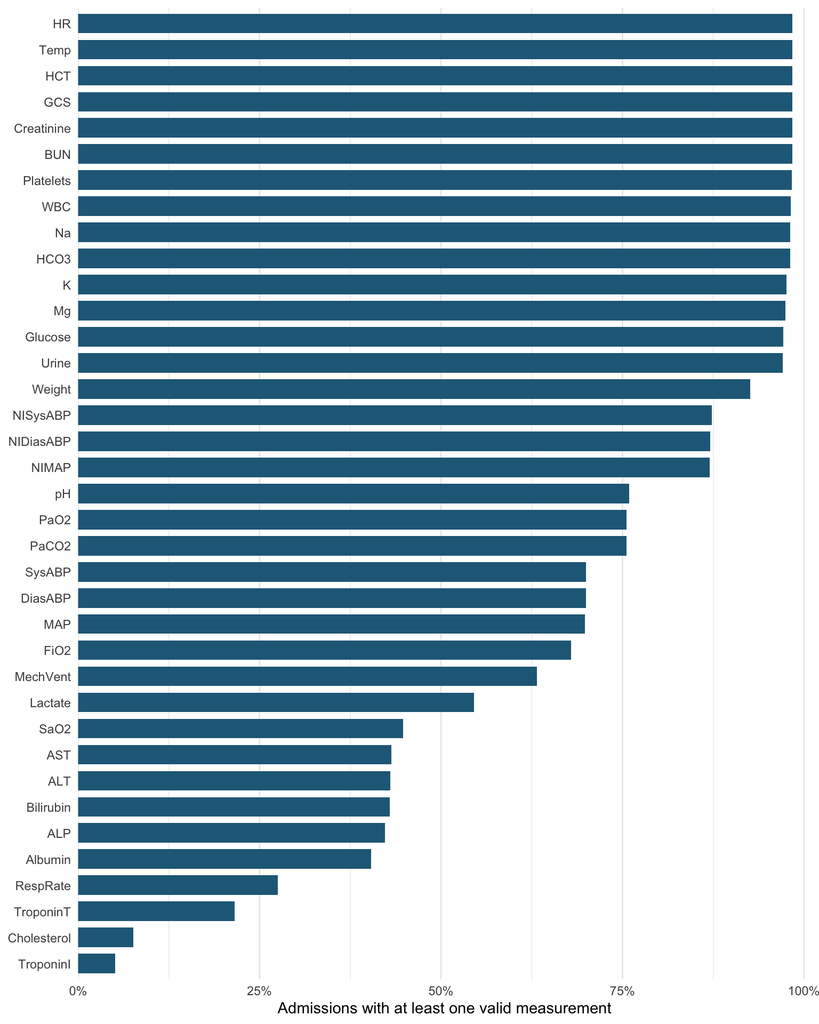

Figure 1: Patients with at least one valid measurement during 0–48 hours. Denominator: all admissions for every variable.

```r
variable_order <- availability$Parameter
plot_overall <- ggplot(availability,aes(x=p_measured,y=factor(Parameter,levels=variable_order)))+
 geom_col(fill="#246987",width=.75)+
 scale_x_continuous(labels=scales::label_percent(),limits=c(0,1),expand=expansion(mult=c(0,.01)))+
 labs(x="Admissions with at least one valid measurement",y=NULL)+
 theme_minimal(base_size=11)+theme(panel.grid.major.y=element_blank())
ggsave(here::here("output","availability-48h.png"),plot_overall,width=8,height=10,dpi=160)
plot_overall
```

```r
knitr::kable(availability[,.(Parameter,n_measured,
 measured_percent=round(100*p_measured,2),missing_percent=round(100*p_missing,2))])
```

| Parameter | n_measured | measured_percent | missing_percent |
| --- | --- | --- | --- |
| TroponinI | 205 | 5.12 | 94.88 |
| Cholesterol | 305 | 7.62 | 92.38 |
| TroponinT | 863 | 21.58 | 78.42 |
| RespRate | 1101 | 27.52 | 72.47 |
| Albumin | 1615 | 40.38 | 59.62 |
| ALP | 1690 | 42.25 | 57.75 |
| Bilirubin | 1718 | 42.95 | 57.05 |
| ALT | 1721 | 43.03 | 56.97 |
| AST | 1725 | 43.12 | 56.88 |
| SaO2 | 1792 | 44.80 | 55.20 |
| Lactate | 2183 | 54.57 | 45.43 |
| MechVent | 2529 | 63.22 | 36.78 |
| FiO2 | 2717 | 67.92 | 32.07 |
| MAP | 2792 | 69.80 | 30.20 |
| DiasABP | 2799 | 69.97 | 30.03 |
| SysABP | 2799 | 69.97 | 30.03 |
| PaCO2 | 3023 | 75.58 | 24.42 |
| PaO2 | 3023 | 75.58 | 24.42 |
| pH | 3038 | 75.95 | 24.05 |
| NIMAP | 3481 | 87.02 | 12.98 |
| NIDiasABP | 3483 | 87.08 | 12.92 |
| NISysABP | 3493 | 87.33 | 12.68 |
| Weight | 3704 | 92.60 | 7.40 |
| Urine | 3883 | 97.08 | 2.92 |
| Glucose | 3887 | 97.17 | 2.82 |
| Mg | 3897 | 97.42 | 2.58 |
| K | 3904 | 97.60 | 2.40 |
| HCO3 | 3924 | 98.10 | 1.90 |
| Na | 3925 | 98.12 | 1.88 |
| WBC | 3927 | 98.17 | 1.82 |
| Platelets | 3932 | 98.30 | 1.70 |
| BUN | 3936 | 98.40 | 1.60 |
| Creatinine | 3936 | 98.40 | 1.60 |
| GCS | 3936 | 98.40 | 1.60 |
| HCT | 3936 | 98.40 | 1.60 |
| Temp | 3936 | 98.40 | 1.60 |
| HR | 3937 | 98.42 | 1.58 |

### Temporal missingness

Each heatmap cell is the proportion of 4000 admissions with at least one valid measurement, regardless of how many measurements that patient had in the bin. Bins are [0,6), [6,12), …, [36,42), and [42,48]. Thus a reading at 06:00 starts the second bin and 48:00 belongs to the last bin. Empty variable/bin cells are explicitly included with zero availability.

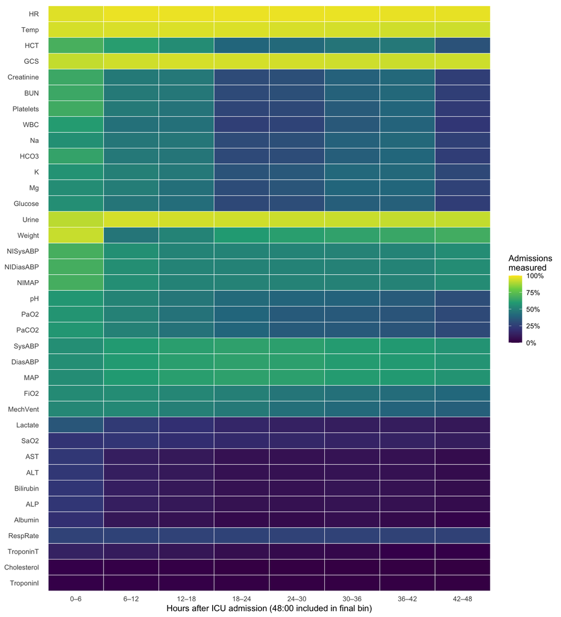

Figure 2: Six-hour measurement availability. Rows are 37 time-series variables; columns are time windows; fill is the proportion of all admissions with a valid measurement.

```r
bin_labels <- c("0–6","6–12","12–18","18–24","24–30","30–36","36–42","42–48")
plot_temporal <- ggplot(temporal,aes(x=factor(bin,levels=1:8,labels=bin_labels),
 y=factor(Parameter,levels=variable_order),fill=p_measured))+
 geom_tile(color="white",linewidth=.25)+
 scale_fill_viridis_c(limits=c(0,1),labels=scales::label_percent(),name="Admissions\nmeasured")+
 labs(x="Hours after ICU admission (48:00 included in final bin)",y=NULL)+
 theme_minimal(base_size=11)+theme(panel.grid=element_blank())
ggsave(here::here("output","availability-6h-heatmap.png"),plot_temporal,width=10,height=11,dpi=160)
plot_temporal
```

### First 24 versus second 24 hours

The first window is [0,24); the second is [24,48], including 48:00. These windows do not overlap. Differences below are second minus first, in percentage points.

```r
half_display <- merge(availability[,.(Parameter,n_measured)],halves,by="Parameter")
setorder(half_display,n_measured,Parameter)
knitr::kable(half_display[,.(Parameter,first_percent=round(100*p_first,2),
 second_percent=round(100*p_second,2),difference_pp=round(difference_pp,2))])
```

| Parameter | first_percent | second_percent | difference_pp |
| --- | --- | --- | --- |
| TroponinI | 4.62 | 2.05 | -2.57 |
| Cholesterol | 6.62 | 1.10 | -5.53 |
| TroponinT | 20.42 | 9.10 | -11.32 |
| RespRate | 27.42 | 27.20 | -0.22 |
| Albumin | 32.75 | 15.85 | -16.90 |
| ALP | 36.68 | 20.35 | -16.33 |
| Bilirubin | 36.78 | 21.48 | -15.30 |
| ALT | 37.35 | 20.82 | -16.53 |
| AST | 37.43 | 20.85 | -16.58 |
| SaO2 | 37.65 | 28.60 | -9.05 |
| Lactate | 48.93 | 26.92 | -22.00 |
| MechVent | 60.08 | 48.77 | -11.30 |
| FiO2 | 63.52 | 52.33 | -11.20 |
| MAP | 66.00 | 64.90 | -1.10 |
| DiasABP | 66.17 | 64.92 | -1.25 |
| SysABP | 66.17 | 64.92 | -1.25 |
| PaCO2 | 71.30 | 57.12 | -14.17 |
| PaO2 | 71.30 | 57.25 | -14.05 |
| pH | 71.58 | 60.40 | -11.18 |
| NIMAP | 78.15 | 66.92 | -11.22 |
| NIDiasABP | 78.25 | 67.05 | -11.20 |
| NISysABP | 78.47 | 67.50 | -10.97 |
| Weight | 92.60 | 67.88 | -24.73 |
| Urine | 96.73 | 95.53 | -1.20 |
| Glucose | 93.33 | 92.22 | -1.10 |
| Mg | 93.20 | 92.40 | -0.80 |
| K | 94.40 | 93.42 | -0.97 |
| HCO3 | 96.75 | 95.43 | -1.32 |
| Na | 96.28 | 95.20 | -1.08 |
| WBC | 96.43 | 95.40 | -1.03 |
| Platelets | 96.73 | 95.50 | -1.23 |
| BUN | 97.50 | 96.20 | -1.30 |
| Creatinine | 97.52 | 96.28 | -1.25 |
| GCS | 98.10 | 97.90 | -0.20 |
| HCT | 97.28 | 96.38 | -0.90 |
| Temp | 98.17 | 97.80 | -0.38 |
| HR | 98.22 | 98.05 | -0.17 |

```r
largest_changes <- halves[order(-abs(difference_pp))][1:5]
knitr::kable(largest_changes[,.(Parameter,first_percent=round(100*p_first,2),
 second_percent=round(100*p_second,2),difference_pp=round(difference_pp,2))],
 caption="Five largest absolute changes between the two windows")
```

Five largest absolute changes between the two windows

| Parameter | first_percent | second_percent | difference_pp |
| --- | --- | --- | --- |
| Weight | 92.60 | 67.88 | -24.73 |
| Lactate | 48.93 | 26.92 | -22.00 |
| Albumin | 32.75 | 15.85 | -16.90 |
| AST | 37.43 | 20.85 | -16.58 |
| ALT | 37.35 | 20.82 | -16.53 |

### Interpretation

Over 48 hours, availability ranges from 5.1% to 98.4%. HCT, Temp, HR are among the most routinely recorded variables, while TroponinI, Cholesterol, TroponinT are much less frequently recorded. This is consistent with some tests being ordered selectively, although these data alone do not establish why a test was ordered.

The largest absolute change between the first and second windows is for Weight: 92.6% to 67.9%. Measurement availability can change over the ICU window. I would keep first- and second-24-hour summaries separate in the initial wide-table design so this timing is not lost. This is a provisional data-summary choice, not a modeling decision.

Missingness here is largely the absence of measurements, rather than explicit NA rows. Measurement patterns may reflect clinical workflow or patient condition, so I would not automatically assume MCAR. This audit does not prove MNAR or a causal explanation. These figures describe whether a measurement exists, not how often it was repeated or whether it is clinically plausible.

## Outcome-file validation

The submitted pipeline reads the grader-provided `data/Outcomes-a.txt` and contains no download step.

```r
outcomes <- fread(outcomes_path,colClasses=list(character="RecordID"),check.names=FALSE)
validate_outcomes(outcomes,ids)
outcome_validation <- data.table(rows=nrow(outcomes),unique_RecordIDs=uniqueN(outcomes$RecordID),
 matched_RecordIDs=sum(outcomes$RecordID %in% ids),
 in_hospital_deaths=sum(outcomes[["In-hospital_death"]]),
 death_proportion=mean(outcomes[["In-hospital_death"]]))
knitr::kable(outcome_validation)
```

| rows | unique_RecordIDs | matched_RecordIDs | in_hospital_deaths | death_proportion |
| --- | --- | --- | --- | --- |
| 4000 | 4000 | 4000 | 554 | 0.1385 |

```r
fwrite(outcome_validation,here::here("output","outcome-validation.csv"))
```

No blanket `-1` conversion is applied to outcomes. In particular, Survival records days to a recorded death; `-1` indicates a survivor under the Challenge definition. The primary outcome is the supplied `In-hospital_death`, not a reconstruction from Survival. Field-specific handling for descriptive summaries is explained below; the original outcome values remain unchanged.

## Wide-table design

Round 2 showed substantial differences in measurement availability between the first and second 24 hours. I therefore keep [0,24) and [24,48] separate while creating one row per admission. Exactly 24:00 and 48:00 belong to the second window; 00:00 belongs to the first. Every in-range observation has one window.

For each of the 37 variables in each window, count records the number of valid observations. First and last retain some ordering information, min/max describe the observed range, and mean gives the average recorded level. First/last use time followed by source order for ties. These are summaries of the observed measurements, not time-weighted averages. All valid tied observations contribute to count/min/max/mean. This is an initial design that can be revised later, not a claim that these are optimal model features.

Numerical summaries use `Value_analysis`: sentinel missing values and the 33 hard-invalid observations are excluded; soft concerns remain. There is no imputation, rescaling, or winsorization. A window with no valid measurements has count 0 and NA for all five numerical summaries.

### Descriptor and timestamp audits

Admission descriptors use time zero only. A missing admission Weight is never replaced by a later Weight. Both AdmissionWeight and repeated Weight summaries are intentionally retained because Weight has both roles in the source data. Identical descriptor duplicates would collapse to the first source row; inconsistent duplicates stop construction for review rather than choosing a value silently. Missing source rows would remain NA and appear in the audit.

```r
built <- build_wide(long_analysis,ids,outcomes)
wide <- built$wide
descriptor_audit <- built$descriptor_audit
dup <- built$duplicates
fwrite(descriptor_audit,here::here("output","descriptor-extraction-audit.csv"))
fwrite(dup,here::here("output","duplicate-timestamp-audit.csv"))
descriptor_summary <- descriptor_audit[,.(expected_pairs=.N,
 missing_source_rows=sum(source_rows==0),duplicate_pairs=sum(source_rows>1),
 inconsistent_pairs=sum(distinct_values>1),minimum_rows=min(source_rows),
 maximum_rows=max(source_rows)),by=Parameter]
knitr::kable(descriptor_summary)
```

| Parameter | expected_pairs | missing_source_rows | duplicate_pairs | inconsistent_pairs | minimum_rows | maximum_rows |
| --- | --- | --- | --- | --- | --- | --- |
| Age | 4000 | 0 | 0 | 0 | 1 | 1 |
| Gender | 4000 | 0 | 0 | 0 | 1 | 1 |
| Height | 4000 | 0 | 0 | 0 | 1 | 1 |
| ICUType | 4000 | 0 | 0 | 0 | 1 | 1 |
| Weight | 4000 | 0 | 0 | 0 | 1 | 1 |

```r
dup_summary <- data.table(duplicate_groups=nrow(dup),
 rows_in_duplicate_groups=sum(dup$rows),extra_rows=sum(dup$rows-1L),
 conflicting_valid_groups=sum(dup$valid_distinct>1))
knitr::kable(dup_summary)
```

| duplicate_groups | rows_in_duplicate_groups | extra_rows | conflicting_valid_groups |
| --- | --- | --- | --- |
| 3730 | 7474 | 3744 | 3724 |

The audit found 3730 duplicated patient/parameter/exact-Time groups; 3724 contain conflicting valid values. Source order makes first/last deterministic without averaging away those disagreements. The raw observations stay intact in the long table.

## Wide-table construction and validation

Columns are RecordID, five admission descriptors, 444 time-series summaries, and five outcome fields: **455 columns**. The summaries follow the fixed 37-variable order, first window then second window, and count/first/last/min/max/mean. For example, `HR_h0_24_mean` and `HR_h24_48_count` identify the variable, window, and statistic. `SAPS-I` is renamed `SAPS_I`, and `In-hospital_death` becomes `In_hospital_death`. Other outcome names and values remain unchanged, including all raw outcome `-1` codes.

```r
wide_path <- here::here("output","set-a_wide.csv")
validate_wide(wide,ids,outcomes)
fwrite(wide,wide_path,na="NA")
wide_read <- fread(wide_path,na.strings="NA",colClasses=list(character="RecordID"))
validate_wide(wide_read,ids,outcomes)
stopifnot(isTRUE(all.equal(wide_read,wide,tolerance=1e-12,check.attributes=FALSE)))
knitr::kable(data.table(rows=nrow(wide_read),columns=ncol(wide_read),
 expected_columns=455,unique_RecordIDs=uniqueN(wide_read$RecordID),
 time_series_columns=length(feature_columns())))
```

| rows | columns | expected_columns | unique_RecordIDs | time_series_columns |
| --- | --- | --- | --- | --- |
| 4000 | 455 | 455 | 4000 | 444 |

Validation includes unique matching IDs, a one-to-one outcome join, unique column names, no Inf/-Inf/NaN, non-negative integer counts, and the correspondence between zero counts and five missing summaries. First/last use valid observations only. Checks also confirm that mean lies between min and max.

`In_hospital_death` is the target. Length_of_stay and Survival contain post-admission outcome information and must not become prediction features. SAPS_I and SOFA are retained for cohort description/evaluation; they are not automatically future predictors merely because they appear in this CSV.

## Wide-table missingness

This figure is calculated **from the read-back wide CSV**. Count is always observed; count 0 means that first/last/min/max/mean are all missing for that variable-window. If count is positive, all five are observed. Those five summaries therefore share a missingness pattern, so plotting each separately would repeat the same information. The fill here is missingness, whereas Round 2’s figures show availability.

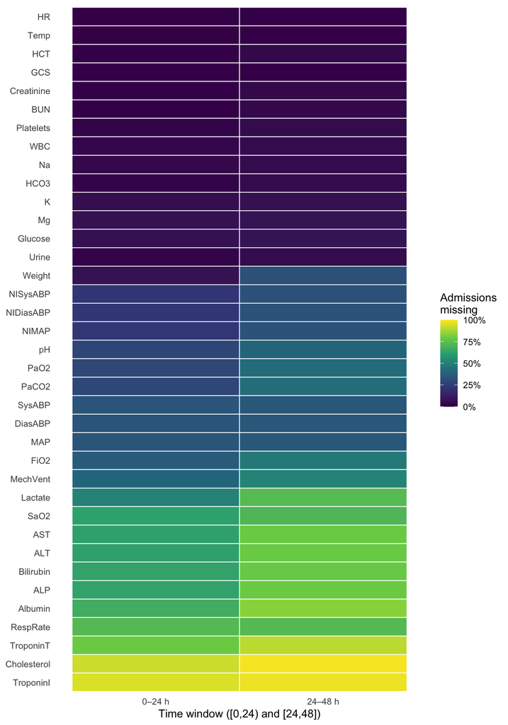

Figure 3: Missingness derived from set-a_wide.csv: percentage of all admissions with count zero in each variable-window.

```r
wide_missing <- wide_missingness(wide_read)
# Independently connect the new wide representation to the validated Round 2 counts.
check_half <- merge(wide_missing,halves,by="Parameter")
stopifnot(all(abs(check_half$p_missing-ifelse(check_half$window=="h0_24",
 1-check_half$p_first,1-check_half$p_second))<1e-12))
fwrite(wide_missing,here::here("output","wide-missingness.csv"))
plot_wide <- ggplot(wide_missing,aes(x=factor(window,levels=window_names,
 labels=c("0–24 h","24–48 h")),y=factor(Parameter,levels=variable_order),fill=p_missing))+
 geom_tile(color="white",linewidth=.35)+
 scale_fill_viridis_c(limits=c(0,1),labels=scales::label_percent(),name="Admissions\nmissing")+
 labs(x="Time window ([0,24) and [24,48])",y=NULL)+
 theme_minimal(base_size=11)+theme(panel.grid=element_blank())
ggsave(here::here("output","wide-missingness.png"),plot_wide,width=7,height=10,dpi=160)
plot_wide
```

### Admission-descriptor missingness from the wide table

```r
wide_descriptors <- c("Age","Gender","Height","ICUType","AdmissionWeight")
wide_descriptor_missing <- rbindlist(lapply(wide_descriptors,function(p)
 data.table(descriptor=p,missing_N=sum(is.na(wide_read[[p]])),
 missing_percent=100*mean(is.na(wide_read[[p]])))))
fwrite(wide_descriptor_missing,here::here("output","wide-descriptor-missingness.csv"))
knitr::kable(wide_descriptor_missing,digits=3)
```

| descriptor | missing_N | missing_percent |
| --- | --- | --- |
| Age | 0 | 0.000 |
| Gender | 3 | 0.075 |
| Height | 1894 | 47.350 |
| ICUType | 0 | 0.000 |
| AdmissionWeight | 326 | 8.150 |

## Table 1

Table 1 describes admission characteristics, stratified by the supplied in-hospital death indicator. Continuous variables use median (Q1, Q3), and categories use n (%) among nonmissing values within each column. Missing counts are shown separately. There are no hypothesis-test p-values. Documented invalid values are missing in analysis; broader plausibility flags remain because there is not enough evidence to correct or remove them.

**Table 1. Admission characteristics by in-hospital outcome**

| **Characteristic** | **Overall** N = 4,000<sup>1</sup> | **Survived** N = 3,446<sup>1</sup> | **Died** N = 554<sup>1</sup> |
| --- | --- | --- | --- |
| Age (years) | 67.0 (52.5, 78.0) | 66.0 (51.0, 78.0) | 74.0 (60.0, 83.0) |
| Missing | 0 | 0 | 0 |
| Gender |  |  |  |
| Female | 1,751 (43.8%) | 1,498 (43.5%) | 253 (45.8%) |
| Male | 2,246 (56.2%) | 1,946 (56.5%) | 300 (54.2%) |
| Missing | 3 | 2 | 1 |
| Height (cm) | 170.2 (162.6, 177.8) | 170.2 (162.6, 177.8) | 170.2 (160.0, 177.8) |
| Missing | 1,894 | 1,601 | 293 |
| ICU type |  |  |  |
| Coronary Care Unit | 577 (14.4%) | 496 (14.4%) | 81 (14.6%) |
| Cardiac Surgery Recovery Unit | 874 (21.9%) | 831 (24.1%) | 43 (7.8%) |
| Medical ICU | 1,481 (37.0%) | 1,206 (35.0%) | 275 (49.6%) |
| Surgical ICU | 1,068 (26.7%) | 913 (26.5%) | 155 (28.0%) |
| Missing | 0 | 0 | 0 |
| Admission weight (kg) | 78.6 (66.0, 92.0) | 79.2 (66.5, 92.3) | 75.0 (61.9, 90.0) |
| Missing | 326 | 298 | 28 |

<sup>1</sup> Median (Q1, Q3); n (%)

Category labels follow the [official PhysioNet definitions](https://physionet.org/content/challenge-2012/1.0.0/). The admission Weight column is independent of later repeated Weight summaries.

## Outcome summary

```r
cohort_totals <- data.table(total_admissions=nrow(wide_read),
 survived=sum(wide_read$In_hospital_death==0),died=sum(wide_read$In_hospital_death==1),
 mortality_percent=100*mean(wide_read$In_hospital_death==1))
stopifnot(cohort_totals$survived+cohort_totals$died==4000L)
knitr::kable(cohort_totals,digits=2)
```

| total_admissions | survived | died | mortality_percent |
| --- | --- | --- | --- |
| 4000 | 3446 | 554 | 13.85 |

```r
severity <- outcome_description(wide_read)
fwrite(severity,here::here("output","outcome-descriptive-summary.csv"))
fwrite(cohort_totals,here::here("output","cohort-totals.csv"))
knitr::kable(severity[,.(field,nonmissing_N,missing_N,
 `Median (Q1, Q3)`=sprintf("%.1f (%.1f, %.1f)",median,q1,q3))])
```

| field | nonmissing_N | missing_N | Median (Q1, Q3) |
| --- | --- | --- | --- |
| Length_of_stay | 3940 | 60 | 10.0 (6.0, 17.0) |
| SAPS_I | 3810 | 190 | 15.0 (11.0, 19.0) |
| SOFA | 3856 | 144 | 7.0 (3.0, 9.0) |

For this table only, the documented missing/unknown code `-1` in SAPS_I, SOFA, and Length_of_stay is treated as missing in separate copies. Their raw values remain in the wide CSV. Length of stay describes the hospitalization rather than a baseline characteristic. Survival is omitted from this numerical table: its `-1` has special survivor semantics and is not an ordinary number of days. Mortality comes directly from In_hospital_death.

## Is the missingness informative?

For each time-series variable, an admission is ever measured when it has at least one valid `Value_analysis` during 0–48 hours, including both endpoints. Sentinels and hard-invalid values do not count; soft flags remain included. Each admission contributes once to either the measured or unmeasured group. Death rates use the supplied in-hospital outcome. Differences below are signed percentage points (measured minus unmeasured), sorted by absolute magnitude. An unavailable rate is shown as NA when its group is empty.

```r
informative <- informative_missingness(long_analysis, ids, outcomes)
stopifnot(all(informative$n_measured + informative$n_not_measured == length(ids)),
          all(informative$deaths_measured + informative$deaths_not_measured ==
              sum(outcomes[["In-hospital_death"]])))
availability_check <- merge(informative, availability, by="Parameter")
stopifnot(all(availability_check$n_measured.x == availability_check$n_measured.y))
fwrite(informative, here::here("output", "informative-missingness.csv"), na="NA")
knitr::kable(informative[, .(Variable=Parameter, `Measured N`=n_measured,
 `Measured death %`=death_pct_measured, `Not measured N`=n_not_measured,
 `Not measured death %`=death_pct_not_measured,
 `Difference (pp)`=difference_pp)], digits=2)
```

| Variable | Measured N | Measured death % | Not measured N | Not measured death % | Difference (pp) |
| --- | --- | --- | --- | --- | --- |
| TroponinI | 205 | 27.80 | 3795 | 13.10 | 14.71 |
| TroponinT | 863 | 21.09 | 3137 | 11.86 | 9.23 |
| AST | 1725 | 19.07 | 2275 | 9.89 | 9.18 |
| ALT | 1721 | 19.06 | 2279 | 9.92 | 9.14 |
| Bilirubin | 1718 | 19.03 | 2282 | 9.95 | 9.09 |
| ALP | 1690 | 19.05 | 2310 | 10.04 | 9.01 |
| WBC | 3927 | 14.01 | 73 | 5.48 | 8.53 |
| Lactate | 2183 | 17.64 | 1817 | 9.30 | 8.34 |
| Albumin | 1615 | 18.76 | 2385 | 10.52 | 8.24 |
| RespRate | 1101 | 7.90 | 2899 | 16.11 | -8.21 |
| Platelets | 3932 | 13.99 | 68 | 5.88 | 8.11 |
| Glucose | 3887 | 14.07 | 113 | 6.19 | 7.88 |
| FiO2 | 2717 | 16.34 | 1283 | 8.57 | 7.77 |
| BUN | 3936 | 13.97 | 64 | 6.25 | 7.72 |
| Creatinine | 3936 | 13.97 | 64 | 6.25 | 7.72 |
| HCT | 3936 | 13.97 | 64 | 6.25 | 7.72 |
| PaCO2 | 3023 | 15.68 | 977 | 8.19 | 7.49 |
| HCO3 | 3924 | 13.99 | 76 | 6.58 | 7.41 |
| PaO2 | 3023 | 15.65 | 977 | 8.29 | 7.36 |
| pH | 3038 | 15.60 | 962 | 8.32 | 7.29 |
| Mg | 3897 | 14.04 | 103 | 6.80 | 7.24 |
| K | 3904 | 14.01 | 96 | 7.29 | 6.72 |
| GCS | 3936 | 13.95 | 64 | 7.81 | 6.14 |
| Temp | 3936 | 13.95 | 64 | 7.81 | 6.14 |
| HR | 3937 | 13.94 | 63 | 7.94 | 6.01 |
| Na | 3925 | 13.96 | 75 | 8.00 | 5.96 |
| Weight | 3704 | 14.28 | 296 | 8.45 | 5.84 |
| MechVent | 2529 | 15.62 | 1471 | 10.81 | 4.81 |
| DiasABP | 2799 | 14.61 | 1201 | 12.07 | 2.54 |
| SysABP | 2799 | 14.61 | 1201 | 12.07 | 2.54 |
| MAP | 2792 | 14.54 | 1208 | 12.25 | 2.29 |
| SaO2 | 1792 | 14.79 | 2208 | 13.09 | 1.70 |
| Cholesterol | 305 | 15.08 | 3695 | 13.75 | 1.33 |
| NIMAP | 3481 | 13.99 | 519 | 12.91 | 1.08 |
| NIDiasABP | 3483 | 13.98 | 517 | 12.96 | 1.02 |
| NISysABP | 3493 | 13.97 | 507 | 13.02 | 0.95 |
| Urine | 3883 | 13.83 | 117 | 14.53 | -0.70 |

Across the 37 variables, mortality differs between measured and unmeasured groups for some variables. Whether a measurement is taken may reflect patient condition and clinical workflow, so I would not automatically treat measurement absence as random. Small unmeasured groups can also produce large, unstable differences. This descriptive comparison does not establish why measurements are missing, establish causality, or prove a formal missingness mechanism. The ordering is only a way to display the table; no hypothesis tests or p-values are used.

## AI use disclosure

I used Codex/ChatGPT substantially for project and repository setup guidance, R code drafting, data wrangling, missingness analysis, wide-table construction, tests and assertions, debugging Pixi and Quarto, explaining statistical and data concepts, and identifying edge cases to review.

The assistance reduced repetitive coding work, suggested useful checks, exposed edge cases, and helped explain unfamiliar tooling. It also introduced risks: AI can make unjustified clinical assumptions, and code can run successfully while implementing the wrong data definition. The initial AI-assisted audit missed some invalid pH values until a broader audit. Environment fixes also became unnecessarily complicated during development. These experiences made checking the definitions and outputs necessary.

The review process used reproducible tests, raw-record spot checks, and separate calculations, including independent Python calculations for selected summaries. Checks covered source-file counts and schemas, filename/internal RecordID agreement, preservation of raw values, the distinction between hard-invalid values and soft flags, boundaries at 24:00 and 48:00, long-to-wide spot checks, and outcome joins. Figures were visually inspected. Locked Pixi execution and a final fresh-clone reproduction were used to check reproducibility and compare the long and wide CSV hashes with the accepted baseline.

Many checks were themselves developed or run with AI assistance; this is not independent human validation of every generated line. Automated checks and separate calculations can expose mistakes, but do not replace my responsibility to personally read the final report and confirm that this disclosure accurately reflects my work before submitting.